# Supremum Augmented Dickey Fuller Test - SADF- Pytorch 3 GPU - PCR

```python
import os
home = os.environ['USERPROFILE']
os.chdir(os.path.join(home, r'Projects\stocks\mt5\python'))
```

```python
import util
import pandas as pd
import datetime
import numpy as np
import importlib
import glob
from matplotlib import pylab as plt
from statsmodels.tsa.stattools import adfuller # stationarity test
import talib as ta
from numba import jit
import sys
```

```python
os.chdir(os.path.join(home, r'Projects\stocks\algos'))
```

```python
import util
import torch as th
```

### Idea go to GPU Supremum Dickey Fuller test

- Cannot thing of one way to make it faster
- Did not make it better (in fact performance is worse using pytorch equal adf size batch)
  - Since there thousand of matrixes but they are small and with different sizes
  - GPU bootleneck is memory i/o making it slower than CPU code GTX 1060 6GB

### Dickey Fuller Test

$$ \Delta y_t = a_0 + a_1t + \delta y_{t-1} + \epsilon_t $$

- $ \epsilon_t $ error term (will be minimized)
- $\Delta$ first difference operator
- $a_0$ drift term
- $a_1$ time trend or deterministic term

for example for $y_t$ in {0, 1, 2 ... 3} the overdetermined system

$$ y_0 = a_0 + a_1 0 + \delta 0 $$$$ y_1-y_0 = a_0 + a_1 1 + \delta y_{0} $$$$ y_2-y_1 = a_0 + a_1 2 + \delta y_{1} $$$$ y_3-y_2 = a_0 + a_1 3 + \delta y_{2} $$

### Augmented Dickey Fuller Test

replacing $a_0=\alpha$, $a1=\beta$ and $\delta=\gamma$ [Wikipedia convention](https://en.wikipedia.org/wiki/Augmented_Dickey%E2%80%93Fuller_test) .

$$ \Delta y_t = \alpha + \beta t + \gamma y_{t-1} + \delta_1 \Delta y_{t-1} + ... + \delta_{p-1} \Delta y_{t-p+1} + \epsilon_t $$

- $ \epsilon_t $ error term (will be minimized)
- $\Delta$ first difference operator
- $\alpha$ drift term
- $\beta$ time trend or deterministic term
- $p$ lag order must be choosen, using for example the Akaike and Schwartz (Bayesian) information criteria.

for example for $y_t$ in {0, 1, 2 ... 8}, N=9 and p=2. the overdetermined system is:

$$ \Delta y_3 = \alpha + \beta 3 + \gamma y_{2} + \delta_1 \Delta y_2 + \delta_2 \Delta y_1 $$$$ \Delta y_4 = \alpha + \beta 4 + \gamma y_{3} + \delta_1 \Delta y_3 + \delta_2 \Delta y_2 $$$$ \Delta y_5 = \alpha + \beta 5 + \gamma y_{4} + \delta_1 \Delta y_4 + \delta_2 \Delta y_3 $$$$ \Delta y_6 = \alpha + \beta 6 + \gamma y_{5} + \delta_1 \Delta y_5 + \delta_2 \Delta y_4 $$$$ \Delta y_7 = \alpha + \beta 7 + \gamma y_{6} + \delta_1 \Delta y_6 + \delta_2 \Delta y_5 $$$$ \Delta y_8 = \alpha + \beta 8 + \gamma y_{7} + \delta_1 \Delta y_7 + \delta_2 \Delta y_6 $$

$$ \begin{pmatrix} 1 & p+1 & y_{p} & \Delta y_{p} & \Delta y_{p-1}& \cdots & \Delta y_{1} \\ 1 & p+2 & y_{p+1} & \Delta y_{p+1} & \Delta y_{p} & \cdots & \Delta y_{2} \\ 1 & p+3 & y_{p+2} & \Delta y_{p+2} & \Delta y_{p+1}& \cdots & \Delta y_{3} \\ \vdots & \vdots & \vdots & \vdots & \vdots & \ddots & \vdots \\ 1 & N-1 & y_{N-2} & \Delta y_{N-2} & \Delta y_{N-3}& \cdots & \Delta y_{N-p-1} \\ \end{pmatrix} \begin{pmatrix} \alpha \\ \beta \\ \gamma \\ \delta_1 \\ \delta_2 \\ \vdots \\ \delta_p \\ \end{pmatrix} = \begin{pmatrix} \Delta y_{p+1}\\ \Delta y_{p+2}\\ \Delta y_{p+3}\\ \vdots \\ \Delta y_{N-1}\\ \end{pmatrix} $$

$$ \mathbf{X}_{N-p-1,3+p} \cdot \mathbf{\beta}_{3+p} = \Delta y_{N-p-1} $$

that is a overdermined last squares problem, using $z = \Delta y$:

$$ \mathbf{X} \cdot \mathbf{\beta} = z $$

The last squares solution is, :

$$ \mathbf{\hat{\beta}} = \left(\mathbf{X}^T \mathbf{X}\right)^{-1} \mathbf{X}^T z $$

The error

$$ \mathbf{\hat{\epsilon}} = z - \mathbf{X} \mathbf{\hat{\beta}}$$

The number of linear equations is:

$$ N_{eq} = N-p-1 $$

The number of parameters being estimated is $\alpha$, $\beta$, $\gamma$ plus p $\delta$'s:

$$ N_p = (p+3) $$

The reduced chi-squared statistic, estimated $\sigma^2$ :

$$ \hat{\sigma}^2 = s^2 = \frac{\mathbf{\hat{\epsilon}}^T \mathbf{\hat{\epsilon}}}{N_{eq}-N_p} $$

the denominator is the statistical degrees of freedom.

If the strict exogeneity does not hold (as is the case with many time series models, where exogeneity is assumed only with respect to the past shocks but not the future ones), then these estimators will be biased in finite samples. The estimated standard error of each coeficient $\mathbf{\hat{\beta}}_j$ is

$$ Var\left(\mathbf{\hat{\beta}}\right) = \sigma^2 Q = s^2 \left(\mathbf{X}^T \mathbf{X}\right)^{-1} $$

The estimate of this standard error is obtained by replacing the unknown quantity $\sigma^2$ with its estimate $s^2$.

Thus the standard error for the parameter $j$ is:

$$ \hat{\sigma}_j = \hat{s.e.}\left(\mathbf{\hat{\beta}}_j \right) = \sqrt{s^2 \left(\mathbf{X}^T \mathbf{X}\right)^{-1}_{jj}} $$

For the specific case of $\mathbf{\hat{\beta}}_3$ ~ $\gamma$

$$ \hat{\sigma}_3 = \hat{s.e.}\left(\mathbf{\hat{\gamma}} \right) = \sqrt{s^2 \left(\mathbf{X}^T \mathbf{X}\right)^{-1}_{33}} $$

The the test statistic for $\mathbf{\hat{\gamma}}$ is

$$ t = \frac{\mathbf{\hat{\gamma}}}{\hat{\sigma}_3} $$

### Exact Solution for $ADF$ or batch size $ADF's$ (equal size)

- Implemented in `pytorch_adf` fully test against `statsmodel`

### Aproximated Solution for $SADF_t$ - batch size $ADF's$ (different sizes)

- for a $SADF_t$ $t$ point
- Start with matrix of the OLS of backward window of maximum length call it $X$
- For each $ADF$ required smaller than the previous zero the number of corresponding lines on $X$
- Implemented on `pytorch_sadft` with numerical errors

### Numerical errors of aproximation for calculating thousands of ADF's at once on GPU/CPU

- Aproximations is : zeroing first i lines of $X$ when doing $(X^T \cdot X)^{-1}$ for doing each smaller $ADF$ in $SADF_t$
  - using LU decomposition `torch.inverse`
- That's reduced by using `cholesky_inverse`| `cholesky_solve` for symmetric positive definite matrixes $X^T \cdot X$ case
- other possibilities to test (don't know if they would be usefull for something)
  - `torch.qr` QR factorization where Q is orthogonal and R upper triangular
    - very commom for OLS solution
  - `torch.lstsq` computes the solution to the least squares problem

### PCR Principal Component Regression

First perform SVD Singular Value Decomposition on $X_{N_{eq},N_{p}}$ matrix:

$$U_{N_{eq},N_{p}}\Delta_{N_{p},N_{p}} V_{N_{p},N_{p}}^T = X $$

For simplicity lets use $ N_{eq} = N$ and $ N_{p} = P$ here

$$U_{N,P}\Delta_{P,P} V_{P,P}^T = X_{N, P} $$

The last squares solution is, :

$$ \mathbf{\hat{\beta}} = \left(\mathbf{X}^T \mathbf{X}\right)^{-1} \mathbf{X}^T z $$

But, whith $ \Delta^2 $ being the diagonal squared of the singular values:

$$ V \Delta^2 V^T = X^T X $$

Let $V_k$ denote the $ p \times k $ matrix with orthonormal columns consisting of the first $k$ columns of $V$

$$ W_{k_{N,k}} = X_{N,P} V_{k_{P,k}} $$

or making the other diagonal entries zeroed `batch approach`

$$ W_{k_{N,P}} = X_{N,P} V_{k_{P,P}} $$

$W_k$ is the matrix of the transformed covariates

The estimated $\hat{\beta} $ is given by:

$$ \hat{\beta}_k = V_k \left(W_k^T W_k\right)^{-1} W_k^T z $$

With this identiy with diagonal matrix of principal values:

$$ \left(W_k^T W_k\right)^{-1} = diag\left[ \frac{1}{\delta_0}, \frac{1}{\delta_1^2}, \cdots, \frac{1}{\delta_{P-1}^2}\right] $$

$$ \hat{\beta}_k = V_k diag\left[ \delta^{-2} \right] W_k^T z $$

The estimated $\sigma^2$ is the same for the classical OLS  
The estimated standard error of each coeficient $\mathbf{\hat{\beta}}_j$ is

$$ Var\left(\mathbf{\hat{\beta}}\right) = s^2 Q $$

Thus the standard error for the parameter $j$ is:

$$ \hat{\sigma}_j = \hat{s.e.}\left(\mathbf{\hat{\beta}}_j \right) = \sqrt{s^2 Q_{jj}} $$

For the specific case of $\mathbf{\hat{\beta}}_3$ ~ $\gamma$

$$ \hat{\sigma}_3 = \hat{s.e.}\left(\mathbf{\hat{\gamma}} \right) = \sqrt{s^2 Q _{33}} $$

The the test statistic for $\mathbf{\hat{\gamma}}$ is

$$ t = \frac{\mathbf{\hat{\gamma}}}{\hat{\sigma}_3} $$

## The most stable form of OLS

## The problem is that SVD is quite slow on GPU due its nature

## Path Aborted!

```python
indata = th.rand(1000)
```

```python
size = len(indata) # number of bars example
maxw = 21*8 # maximum .... 3 months
p=20
#minw = 21*4 # mininum window size for serial correlation analyses
minw = int((2*p+4)*1.5)
print(maxw-minw, size, minw, 2*p+4) # number of calculations per t value
```

```
102 1000 66 44
```

```python
dev = th.device('cpu')
```

```python
th.set_grad_enabled(False)
n = indata.size()[0]
nobs = n-p-1 # data used for regression
X = th.zeros((n-p-1, 3+p), device=dev, dtype=th.float32)
y = th.tensor(indata, device=dev, dtype=th.float32)

diffilter = th.tensor([-1., 1.], device=dev, dtype=th.float32).view(1, 1, 2)
dy = th.conv1d(y.view(1, 1, -1), diffilter).view(-1)
z = dy[p:].clone()
# X matrix
X[:, 0] = 1 # drift
X[:, 1] = th.arange(p+1, n) # deterministic trend
X[:, 2] = y[p:-1]# regression data (nobs)
# fill in columns, max lagged serial correlations
for i in range(1, p+1):
    X[:, 2+i] = dy[p-i:-i]

# subtract the mean of every row - giving clolesky singular
# X = X.sub(X.mean(-1).repeat(23, 1).t())
# sadf loop until minw, every matrix is smaller than the previous
# zeroing i lines, observations are becomming less also
batch_size = maxw-minw
Xb = X.repeat(batch_size, 1).view(batch_size, X.shape[0], X.shape[1])
zb = z.repeat(batch_size, 1).view(batch_size, X.shape[0], 1) # additonal dim for matrix*vector mult.
nobsi = th.zeros(batch_size, dtype=th.float32)

ststats = np.zeros(batch_size)
#zeromask = th.ones(batch_size, nobs, dtype=th.float32)
for i in range(batch_size): # each is smaller than previous
    Xb[i, :i, :] = 0
    zb[i, :i] = 0
    nobsi[i] = n-(float(i)+2*p+4)
    sXb = X[i:, :]
    szb = z[i:]
    sXt = sXb.t()
    sL = th.cholesky(th.matmul(sXt, sXb))
    sGi = th.cholesky_solve(th.eye(p+3), sL) # ( X^T . X ) ^-1
    # how to ignore i first lines  of bmm(Xt, zbt)
    sXtz= th.matmul(sXt, szb)
    sBhat = th.matmul(sGi, sXtz)
    szhat = th.matmul(sXb, sBhat) #*zeromask.unsqueeze(-1)  # estimated z
    # need to zeroing zhat entries
    # each lines must b
    ser = (szb - szhat) #*zeromask.unsqueeze(-1) # zeromask # hadamart product
    sBhat = sBhat.squeeze()
    ss2 = th.matmul(ser.t(), ser).view(-1)/nobsi[i]
    ststats[i] = sBhat[2]/th.sqrt(ss2*sGi[2,2])

# remove mean of every row
Xb.sub(Xb.mean(-1).repeat(Xb.shape[-1], 1).view(Xb.shape[::-1]).transpose(0, -1))

##### PCR
pcrlimit = 0.1
# principal component regression PCR
U, S, V = th.svd(Xb)
# zero eigenvalues smaller than threshold (pcrlimit)
# S*S are the principal values
Sk = th.where(S <= th.tensor(pcrlimit, device=dev), th.tensor(0.0, device=dev), th.tensor(1.0, device=dev))
V = Sk.repeat(1, X.shape[1]).view(V.shape)*V # choose only the first, V_k
W = th.bmm(Xb, V)
Wt = W.transpose(1, -1)
# L = th.cholesky(Wt.bmm(W))
WtWi = th.diag_embed(1/(S*S)) # th.cholesky_solve(th.eye(p+3), L)
VWtWi = V.bmm(WtWi)
Bhat_ = VWtWi.bmm(Wt.bmm(zb))
Q = VWtWi.bmm(V.transpose(1,-1))
er_ = zb - Xb.bmm(Bhat_)
Bhat_ = Bhat_.squeeze()
s2_ = th.matmul(er_.transpose(1, -1), er_).view(-1)/nobsi
tstats_ = Bhat_[:, 2]/th.sqrt(s2_*Q[:, 2,2])
tstats_ = tstats_.data.numpy()

# Xt = Xb.transpose(1, -1)
# ##### PCR
# L = th.cholesky(th.bmm(Xt, Xb))
# Gi = th.cholesky_solve(th.eye(p+3), L) # ( X^T . X ) ^-1
# # how to ignore i first lines  of bmm(Xt, zbt)
# Xtz= th.bmm(Xt, zb)
# Bhat = th.bmm(Gi, Xtz)
# # need to zeroing zhat entries
# # each lines must b
# er = (zb - Xb.bmm(Bhat)) #*zeromask.unsqueeze(-1) # zeromask # hadamart product
# Bhat = Bhat.squeeze()
# s2 = th.matmul(er.transpose(dim0=1, dim1=-1), er).view(-1)/nobsi
# tstats = Bhat[:, 2]/th.sqrt(s2*Gi[:, 2,2])

#tstats = tstats.data.numpy()
#return tstats.data.numpy(), Gi.sum(1).sum(1).data.numpy()
```

$$ \hat{\beta}_k = V_k \left(W_k^T W_k\right)^{-1} W_k^T z $$$$ Q = V_k \left(W_k^T W_k\right)^{-1} V_k^T $$

```python
er_.shape
```

```
torch.Size([102, 979, 1])
```

```python
Bhat_.shape
```

```
torch.Size([102, 23])
```

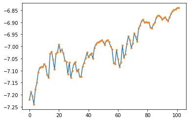

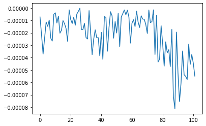

```python
plt.plot(tstats_)
plt.plot(ststats,'.')
plt.figure()
plt.plot(np.abs(tstats_-ststats)/(ststats+1))
```